# NHL Salary Model Generation for 2016/2017 Season

## Background

In professional sports, one of the biggest questions that management has to continually evaluate is whether or not the players they are investing in are providing tangible, measureable results. This is a fundamental concept that plays an integral role in trade considerations, contract negotations, and many other aspects of team management. While it’s difficult to accurately determine a player’s value to a team over the course of just one season (injuries, personnel changes, individual roles on the team, etc. vary from year to year), it is nevertheless useful for teams to gather performance metrics and compare their players’ performance and salaries to those of other players around the league.

## Loading Packages and Data

Loading required packages

```r
require(caret)
require(xgboost)
require(plyr)
require(tidyverse)
require(ggplot2)
require(lubridate)
require(rvest)
require(onehot)
require(ggrepel)
require(scales)
```

Loading in training and testing data and then temporarily combining them into one data.frame

```r
set.seed(314)
train <- read.csv("C:\\Users\\Bryan\\Google Drive\\Kaggle\\Hockey\\train.csv", stringsAsFactors = FALSE)
test.x <- read.csv("C:\\Users\\Bryan\\Google Drive\\Kaggle\\Hockey\\test.csv", stringsAsFactors = FALSE)
test.y <- read.csv("C:\\Users\\Bryan\\Google Drive\\Kaggle\\Hockey\\test_salaries.csv", stringsAsFactors = FALSE)
test <- cbind(test.y, test.x)
rm(test.x); rm(test.y)
all.players <- rbind(train, test)
rm(test); rm(train)
```

## Data Cleaning and Feature Generation

There is a lot of potentially significant information to gather from a player’s date of birth. Extracting age and month of birth from DOB.

```r
all.players$Born <- ymd(all.players$Born)
all.players <- all.players %>% mutate(exactage = time_length(as.duration(interval(all.players$Born, Sys.Date())), "year"),
                                      monthbirth = as.factor(month(all.players$Born)),
                                      yearbirth = as.numeric(year(all.players$Born))) %>%
                               mutate(floorage = floor(exactage))
```

Taking a look at each players age plotted against their salary shows a noticeable trend. Jaromir Jagr, the name on the far right side of the plot, is a well known outlier.

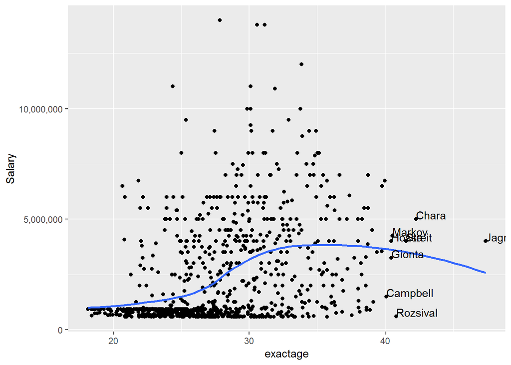

```r
p <- ggplot(data = all.players, aes(x = exactage, y = Salary, label = Last.Name)) + geom_point()
p <- p + scale_y_continuous(labels = scales::comma)
p <- p + geom_smooth(method = "loess", formula = y ~ x, se = FALSE)
p <- p + geom_text(aes(label = ifelse(exactage > 40 , as.character(Last.Name), "")), hjust=0, vjust=0)
plot(p)
```

The state in which each player is from isn’t applicable to every country. Adding “INT” factor to those entries.

```r
all.players$Pr.St[all.players$Pr.St == ""] <- "INT"
all.players$Pr.St <- as.factor(all.players$Pr.St)
```

Native country could be a useful predictor in player salaries. It is common knowledge that many NHL players are native to a small handful of countries.

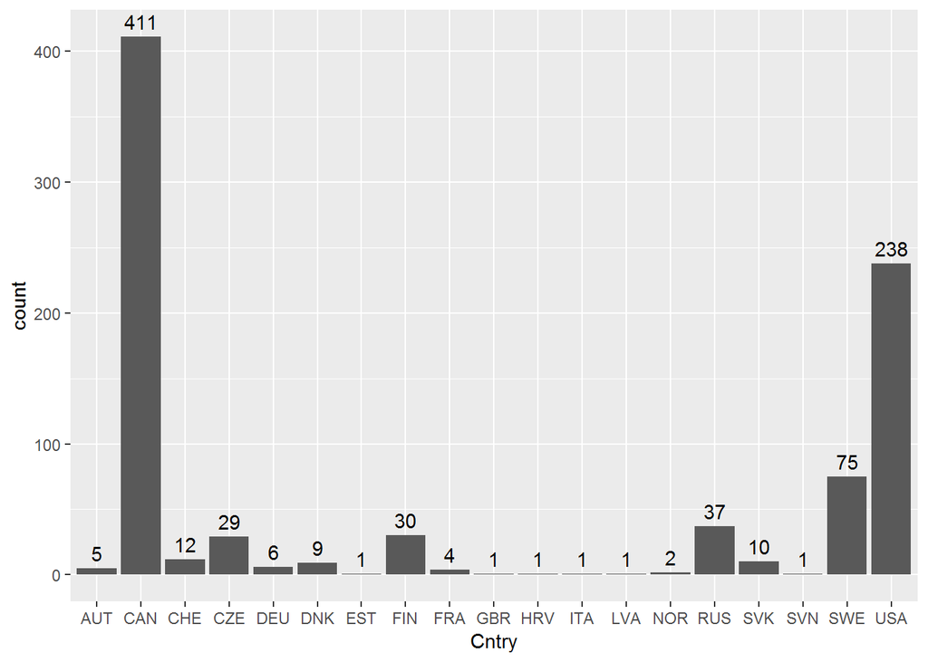

```r
ct <- as.data.frame(table(all.players$Cntry))
p <- ggplot(data = all.players, aes(x = Cntry)) + geom_bar()
p <- p + geom_text(data = ct, aes(x = Var1, y = Freq, label = Freq), vjust = -0.5)
plot(p)
```

Since several players’ countries are represented so few times, there is little statistical value to be gained from them. Converting all countries represented by fewer than 5 players to an ‘International’ tag.

```r
low.pop <- c("EST", "GBR", "HRV", "ITA", "NOR", "SVN", "LVA", "FRA")
all.players <- all.players %>% mutate(Cntry = ifelse(Cntry %in% low.pop, "INT", Cntry),
                                      Nat = ifelse(Nat %in% low.pop, "INT", Cntry))
```

Examining the distribution of players’ home cities

```r
ct <- as.data.frame(table(all.players$City))
ct <- ct[order(ct$Freq, decreasing = TRUE),]
head(ct, 50)
```

```
##            Var1 Freq
## 430     Toronto   36
## 105    Edmonton   23
## 479    Winnipeg   14
## 56      Calgary   13
## 410   Stockholm   13
## 309      Ottawa   10
## 347      Regina   10
## 229      London    9
## 258 Mississauga    9
## 149    Hamilton    8
## 266      Moscow    8
## 256 Minneapolis    7
## 261    Montreal    7
## 39       Boston    6
```

[output cut: 36 more lines]

There appear to be a small handful of cities from which numerous player come from. Any city from which more than 5 players come from shall be denoted as a ‘Hub’.

```r
ct <- ct[ct$Freq > 5,]
all.players$hub <- ifelse(all.players$City %in% ct$Var1, 1, 0)
all.players <- select(all.players, -City)
```

Converting character variables to factors

```r
all.players$Cntry <- as.factor(all.players$Cntry)
all.players$Nat <- as.factor(all.players$Nat)
```

Creating additional factor levels to account for players who were undrafted

```r
all.players$Drafted <- ifelse(is.na(all.players$DftYr) == TRUE, 0, 1)
all.players$DftYr[is.na(all.players$DftYr)] <- all.players$Born[is.na(all.players$DftYr)] + 20
all.players$DftRd[is.na(all.players$DftRd)] <- max(all.players$DftRd, na.rm = TRUE) + 1
all.players$Ovrl[is.na(all.players$Ovrl)] <- max(all.players$Ovrl, na.rm = TRUE) + 1
temp.draft <- data.frame(year(all.players$Born), all.players$DftYr)
names(temp.draft) <- c("born", "draft")
temp.draft <- temp.draft[temp.draft$draft != 0,]
temp.draft <- apply(temp.draft, 2, as.numeric)
temp.draft <- round(aggregate(draft ~ born, data = temp.draft, mean))
mean.draft.age <- round(mean(temp.draft$draft - temp.draft$born)) + 1
all.players <- all.players %>% mutate(leagueyears = ifelse(DftYr == 0, (as.numeric(yearbirth) + mean.draft.age), (2017 - as.numeric(DftYr))),
                                      DftYr = as.numeric(DftYr),
                                      DftRd = as.numeric(DftRd))
rm(temp.draft)
all.players <- select(all.players, -Born)
```

Examining salary distribution based on dominant hand usage. The distributions are similar though not identical, indicating the possibility that handedness can be a predictor of player salary.

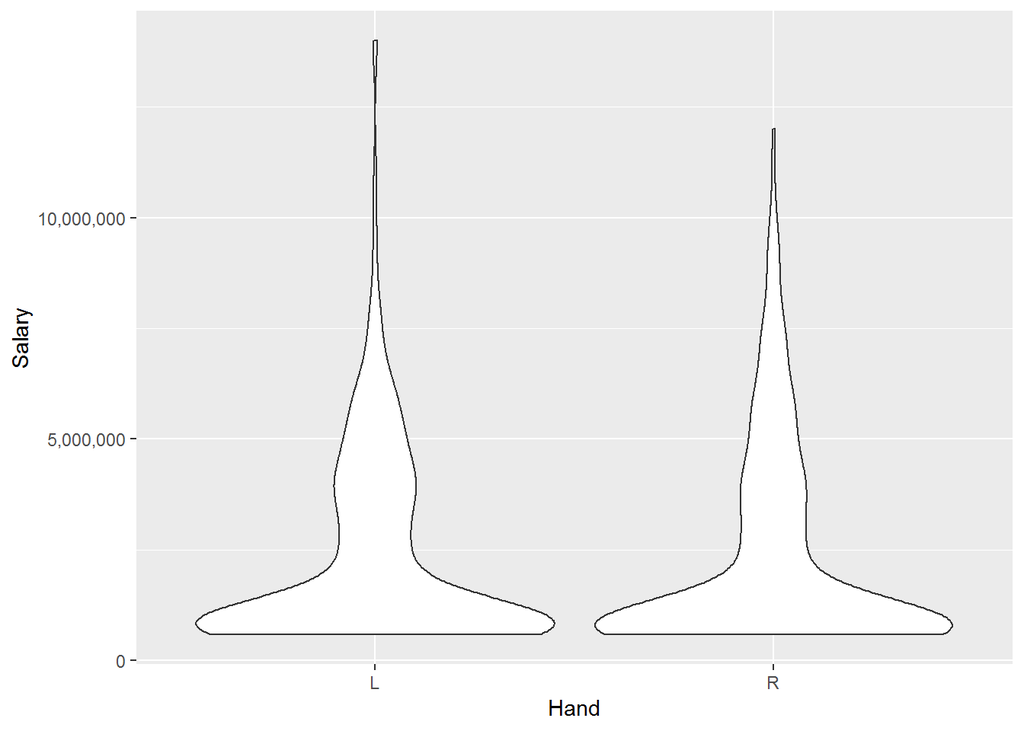

```r
p <- ggplot(data = all.players, aes(x = Hand, y = Salary, labels = Hand)) + geom_violin()
p <- p + scale_y_continuous(labels = scales::comma)
plot(p)
```

One hotting factor variable for handedness

```r
all.players <- all.players %>% mutate(Hand = ifelse(Hand == "L", 1, 0))
```

Some players played multiple positions, so additional features have to be added to account for that

```r
all.players <- all.players %>% mutate(numpos = str_count(Position, "/") + 1) %>%
      separate(col = Position,
               into = c("primpos", "secpos", "tertpos"),
               sep = "/",
               fill = "right")
all.players <- all.players %>% mutate(lwpos = ifelse(all.players$primpos == "LW" |
                                                           all.players$secpos == "LW" |
                                                           all.players$tertpos == "LW", 1, 0),
                                      rwpos = ifelse(all.players$primpos == "RW" |
                                                           all.players$secpos == "RW" |
                                                           all.players$tertpos == "RW", 1, 0),
                                      cpos = ifelse(all.players$primpos == "C" |
                                                          all.players$secpos == "C" |
                                                          all.players$tertpos == "C", 1, 0),
                                      dpos = ifelse(all.players$primpos == "D" |
                                                          all.players$secpos == "D" |
                                                          all.players$tertpos == "D", 1, 0))
all.players$lwpos[is.na(all.players$lwpos)] <- 0
all.players$rwpos[is.na(all.players$rwpos)] <- 0
all.players$cpos[is.na(all.players$cpos)] <- 0
all.players$dpos[is.na(all.players$dpos)] <- 0
all.players <- within(all.players, rm(primpos, secpos, tertpos))
```

The amount of money that teams can afford to spend on players is influenced by global and local factors. Macroeconomic international considerations such as exchange rates, taxes, and so forth have historical relevance to salaries large and small. Most NHL teams are based in the United States, but some are located in Canada; this is something that should be noted.

```r
canadian.teams <- c("TOR", "VAN", "CGY", "WPG", "OTT", "MTL", "EDM")
```

Additionally, because of in-season trades, some players played for multiple teams over the course of the season.

```r
all.players <- all.players %>% mutate(numteam = str_count(Team, "/") +1) %>%
      separate(col = Team,
               into = c("team1", "team2"),
               sep = "/",
               extra = "drop",
               fill = "right") %>%
      mutate(team2 = ifelse(is.na(team2), team1, team2)) %>%
      mutate(team1can = ifelse(team1 %in% canadian.teams, 1, 0),
             team2can = ifelse(team2 %in% canadian.teams, 1, 0),
             team1 = as.factor(team1),
             team2 = as.factor(team2))
```

Combining name fields

```r
all.players <- all.players %>% mutate(fullname = paste(First.Name, Last.Name, sep = " ")) %>%
      select(-First.Name, -Last.Name)
```

Creating a separate data table for team analysis after the player salary predictions are made prior to one-hotting factor variables

```r
predict.roster <- select(all.players, fullname, team1, team2, numteam, Salary)
```

One intangible factor in determining a player’s value to a team is in his ability to lead. Team captains and alternates are generally older and are chosen because those players are the ones that other’s look to for leadership. The original data did not contain this information, so it had to be scraped from another site.

```r
caps <- read_html("https://www.sporcle.com/games/Flyersfan16/2016-17-nhl-captain-and-alternate-captain-nationality")
caps <- rbind(caps %>% html_nodes("table") %>% .[[2]] %>% html_table(),
              caps %>% html_nodes("table") %>% .[[3]] %>% html_table(),
              caps %>% html_nodes("table") %>% .[[4]] %>% html_table())
caps <- select(caps, -Country)
names(caps) <- c("team", "name")
caps <- separate(caps, team, into = c("teamname", "type"), sep = ";")
caps$type <- trimws(caps$type)
all.players <- merge(all.players, caps, by.x = "fullname", by.y = "name", all.x = TRUE, all.y = FALSE)
all.players <- select(all.players, -teamname)
all.players$type <- as.numeric(gsub(".*a.*", 1, all.players$type))
all.players$type[is.na(all.players$type)] <- 0
rm(caps)
```

Converting several fields to ‘numerical’ data

```r
ints <- which(sapply(1:ncol(all.players), function(x) is.integer(all.players[,x])))
for (i in ints) {
      all.players[,i] <- as.numeric(all.players[,i])
}
```

Separating player names from data set for later use

```r
p.names <- all.players$fullname
all.players <- select(all.players, -fullname, -Pr.St)
```

One-hotting additional factor variables

```r
factor.vars <- which(sapply(1:ncol(all.players), function(x) class(all.players[,x])) == "factor")
oh <- onehot(all.players[,factor.vars], max_levels = 32)
oh.df <- as.data.frame(predict(oh, all.players))
all.players <- as.data.frame(cbind(all.players, oh.df))
all.players <- all.players[,-factor.vars]
rm(oh.df)
```

Imputing NA data with median values for each corresponding feature

```r
nas <- which(colSums(is.na(all.players)) > 0)
for (i in nas) {
      all.players[is.na(all.players[,i]),i] <- as.numeric(median(all.players[,i], na.rm = TRUE))
}
```

Plotting player salary

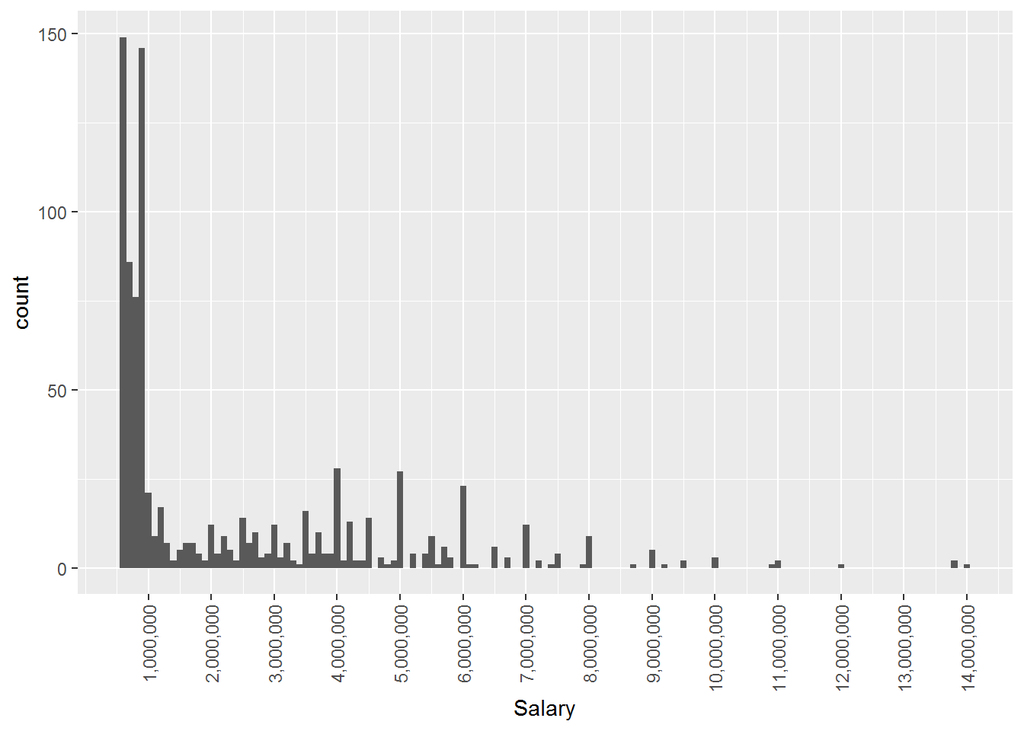

```r
bw <- 1e5
p <- ggplot(data = all.players, aes(x = Salary))
p <- p + geom_histogram(binwidth = bw, bins = ceiling((max(all.players$Salary) - min(all.players$Salary))/bw))
p <- p + scale_x_continuous(labels = scales::comma, breaks = (1:floor(max(all.players$Salary)/1e6)*1e6))
p <- p + theme(axis.text.x = element_text(angle = 90, hjust = 1, vjust = 0.5))
plot(p)
```

## Model Creation

Splitting data into training and test sets.

```r
set.seed(314)
intrain <- createDataPartition(all.players$Salary, p = 0.7, list = FALSE)
test.set <- all.players[-intrain,]
train.set <- all.players[intrain,]
```

Creating gradient boosted tree model

```r
train.x <- select(train.set, -Salary)
train.y <- select(train.set, Salary)
test.x <- select(test.set, -Salary)
test.y <- select(test.set, Salary)

tg <- list(max_depth = 5,
           eta = 0.005,
           gamma = 0,
           colsample_bytree = 1,
           min_child_weight = 0.5,
           subsample = 1,
           objective = "reg:linear")

train.x <- as.matrix(train.x)
train.y <- as.matrix(train.y)
test.y <- as.matrix(test.y)
test.x <- as.matrix(test.x)

xt <- xgboost(data = train.x,
              label = train.y,
              params = tg,
              nrounds = 7000,
              verbose = 0)
```

Applying the model to test set and computing root mean square error for gradient boosted trees model

```r
xt.predict <- predict(xt, test.x)
RMSE(xt.predict, test.y)
```

```
## [1] 1245688
```

The league minimum salary for the 2016-2017 season was $575,000. The GBM model does quite a good job of picking up on that.

```r
range(xt.predict)
```

```
## [1]  578232.2 8612646.0
```

Plotting the top 25 most predictive variables for the model

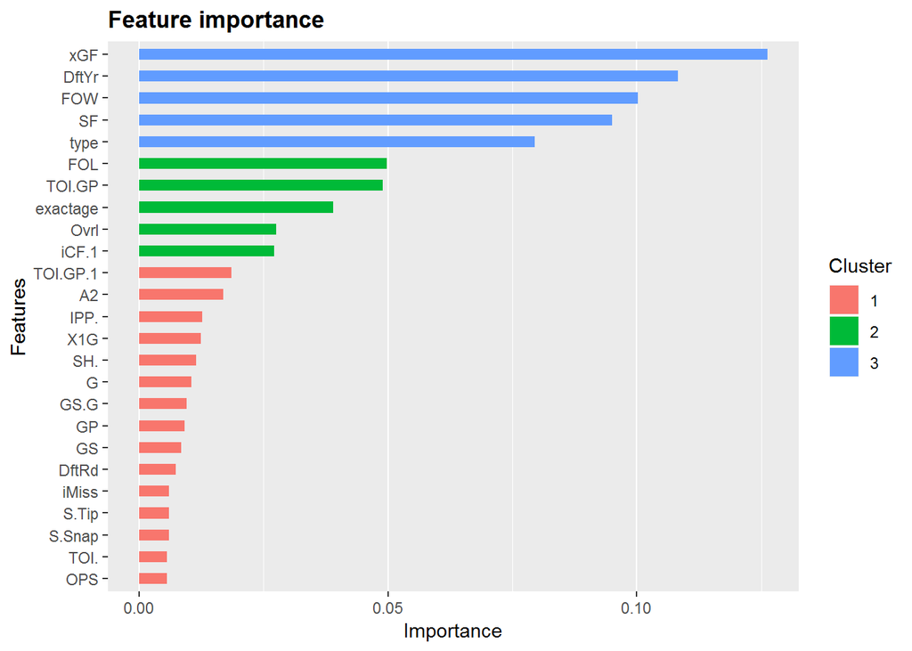

```r
xt.imp <- xgb.importance(model = xt)
xgb.ggplot.importance(importance_matrix = xt.imp, top_n = 25)
```

## Predictions and Visualizations of Results

Generating data.frame of test set predictions and identifying the predictions with the greatest error

```r
prediction.roster <- data.frame(player = p.names[-intrain],
                                prediction = xt.predict,
                                salary = as.numeric(test.set$Salary))
prediction.roster$distance <- round(abs(prediction.roster$salary - prediction.roster$prediction)/sqrt(2))
prediction.roster$error <- prediction.roster$distance/prediction.roster$salary
top5 <- quantile(prediction.roster$distance, prob = c(0.95), type = 5)
```

Plotting graph that shows test set predictions vs actual salaries and their respective distance from a theoretical ideal fit

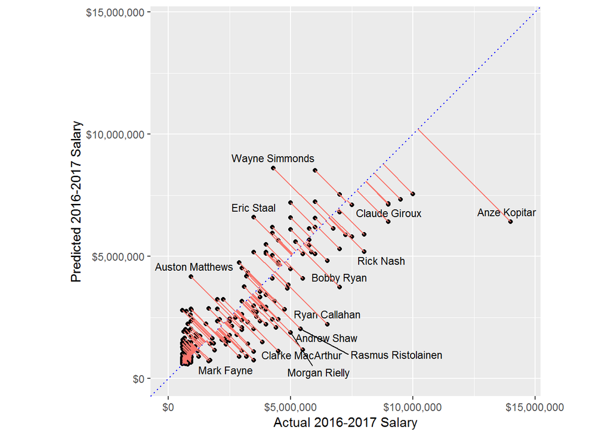

```r
p <- ggplot(data = prediction.roster, aes(x = salary, y = prediction, label = player))
p <- p + geom_jitter()
p <- p + scale_y_continuous(labels = dollar_format())
p <- p + scale_x_continuous(labels = dollar_format())
p <- p + geom_text_repel(aes(label = ifelse(prediction.roster$distance >= top5, as.character(player), ""), vjust = -0.75), size = 3)
p <- p + coord_fixed(ratio = 1, xlim = c(0,14500000), ylim = c(0,14500000), expand = TRUE, clip = "on")
p <- p + geom_abline(slope = 1, intercept = 0, color = "blue", linetype = 3)
p <- p + geom_segment(aes(xend = (salary + prediction)/2, yend = (salary + prediction)/2, color = "red"))
p <- p + theme(legend.title = element_blank(), legend.position = "none")
p <- p + labs(x = "Actual 2016-2017 Salary", y = "Predicted 2016-2017 Salary")
plot(p)
```

Aggregating total team salaries and predicted salaries based on performance metrics. For players who were traded during the course of the season, their projected and actual salaries were halved and those values were applied to both teams they played for.

```r
all.predictions <- predict(xt, as.matrix(select(all.players, -Salary)))
predict.roster <- as.data.frame(cbind(predict.roster, all.predictions))
names(predict.roster) <- c("fullname", "team1", "team2", "numteam", "actualsalary", "predictedsalary")
predict.roster <- predict.roster %>% mutate(predictedsalary = ifelse(numteam > 1, predictedsalary/2, predictedsalary),
                                            actualsalary = ifelse(numteam > 1, actualsalary/2, actualsalary)) %>%
                                     select(-numteam, -fullname)
bp.roster <- select(predict.roster, -team2)
ep.roster <- select(predict.roster, -team1)
names(bp.roster) <- names(ep.roster) <- c("team", "actualsalary", "predictedsalary")
predict.roster <- unique(rbind(bp.roster, ep.roster))
predict.roster <- aggregate(.~team, data = predict.roster, FUN = sum)
predict.roster$team <- as.character(predict.roster$team)
predict.roster <- merge(predict.roster, predict.roster, by.x = c("team", "predictedsalary"), by.y = c("team", "predictedsalary"))
names(predict.roster) <- c("team", "predictedsalary", "actualsalary", "ranksalary")
```

## Final Analysis

Ultimately, the goal of each team every season is to make the playoffs. It is interesting to note that Actual Team Salaries have a greater statistical significance than Predicted Team Salaries when it comes to making the playoffs.

```r
playoff.teams <- c("MTL", "NYR", "OTT", "BOS", "WSH", "TOR", "CBJ", "PIT", "CHI", "NSH", "MIN", "STL", "ANA", "CGY", "EDM", "S.J")
predict.roster <- predict.roster %>% mutate(playoff = ifelse(team %in% playoff.teams, 1, 0))

summary(aov(playoff ~ actualsalary, data = predict.roster))
```

```
##              Df Sum Sq Mean Sq F value Pr(>F)
## actualsalary  1  1.185  1.1846    5.28 0.0293 *
## Residuals    28  6.282  0.2244
## ---
## Signif. codes:  0 '***' 0.001 '**' 0.01 '*' 0.05 '.' 0.1 ' ' 1
```

```r
summary(aov(playoff ~ predictedsalary, data = predict.roster))
```

```
##                 Df Sum Sq Mean Sq F value Pr(>F)
## predictedsalary  1  0.111  0.1107   0.421  0.522
## Residuals       28  7.356  0.2627
```

As suggested by the ANOVA results, there is a high correlation between the teams that made the playoffs and the team’s actual salary (with a handful of notable exceptions). The graph below shows teams ranked in order of decreasing salary; non-faded bars represent teams that made the playoffs. It’s easy to see that a majority of playoff teams fall in the upper half of the total salary range.

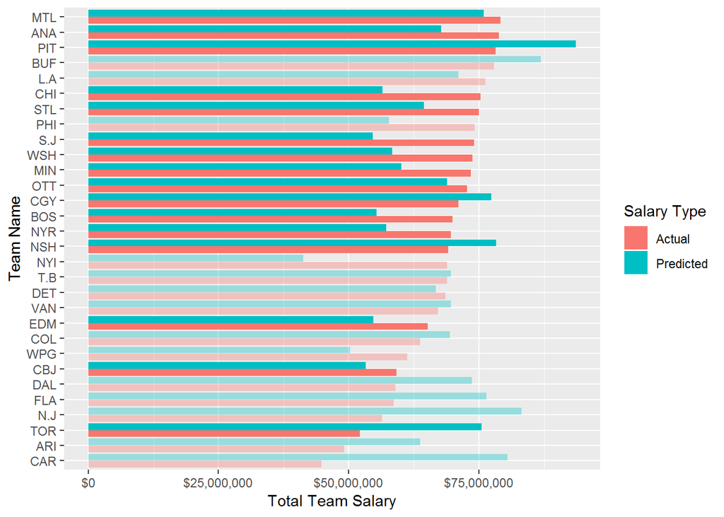

```r
predict.roster <- gather(data = predict.roster, key = "type", value = "salary", actualsalary, predictedsalary)

p <- ggplot(data = predict.roster, aes(x = reorder(team, ranksalary), y = salary,
                                       fill = factor(type, labels = c("Actual", "Predicted")), alpha = playoff))
p <- p + geom_col(position = "dodge")
p <- p + scale_alpha_continuous(range = c(0.35, 1), guide = FALSE)
p <- p + scale_y_continuous(labels = dollar_format())
p <- p + labs(x = "Team Name", y = "Total Team Salary", fill = "Salary Type")
p <- p + coord_flip()
plot(p)
```

On the flipside, the aggregated predicted team salaries do not display a high correlation. While the model accurately projected the overall winner (Pittsburgh), it’s clear that a number of playoff teams were predicted to have low total salaries and some teams projected to have higher total salaries did not. This is the same graph as above, except that it’s been sorted by predicted salary rather than actual salary.

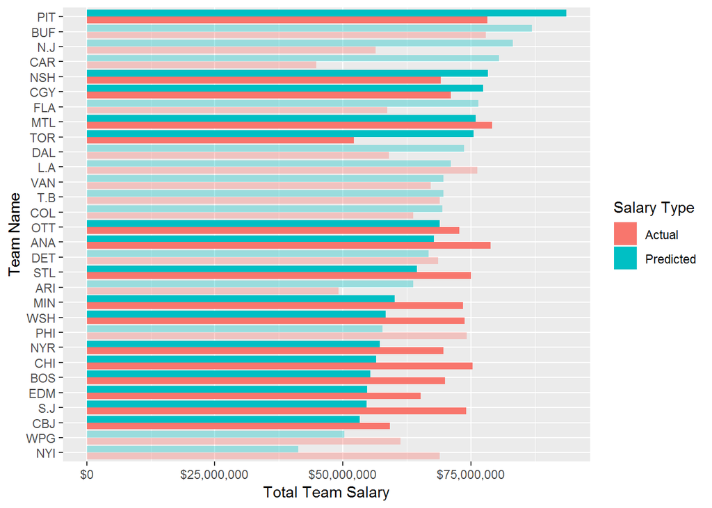

```r
predict.roster <- spread(data = predict.roster, key = "type", value = "salary")
predict.roster <- predict.roster %>% mutate(ranksalary = predictedsalary)
predict.roster <- gather(data = predict.roster, key = "type", value = "salary", actualsalary, predictedsalary)

p <- ggplot(data = predict.roster, aes(x = reorder(team, ranksalary), y = salary,
                                   fill = factor(type, labels = c("Actual", "Predicted")), alpha = playoff))
p <- p + geom_col(position = "dodge")
p <- p + scale_alpha_continuous(range = c(0.35, 1), guide = FALSE)
p <- p + scale_y_continuous(labels = dollar_format())
p <- p + labs(x = "Team Name", y = "Total Team Salary", fill = "Salary Type")
p <- p + coord_flip()
plot(p)
```

The results here demonstrate the old adage that a team is more than a collection of individuals performances. It appears that potentially unquantifiable aspects of team building and management are very significant when it comes to a teams’ success.